# Analyse the strength of associations between binary or binomial distributed outcomes and exposure variables

### Goals

- Recognize when logistic regression can be used,
  - dependent variable is dichotomous or binary
  - predicator (independent) variables can be continuous or categorical. They are related to the probability or odds of the outcome variable.

#### Example

Suppose that we are interested in the factors that influence whether a ESBL E.Coli is present or not in food samples. The outcome (response) variable is binary (0/1); no present or present. The predictor variables of interest are the origin of the food and the type of food.

- Interpret significance testing
- Appraise whether confounding or interactions are present
- Interpret logistic regression output

### Topics

- What is logistic regression?
  - The process of fiting a line or a curve is called regression
  - We use regression analysis to estimate relatioships among variables
  - In particular: the relationship between a dependent and 1 or more independent variables
  - The formal representation of a relationship is an **statistical model**
  - $$p(X)=\beta_0+\beta_1X$$
  - The problem with this approach is that when fiting a straight line for a binary dependent variable the probability $p(x)$ for some values of $X$ can go above 1 or below 0. See the following Figure. The probability of Y goes below zero to above one.

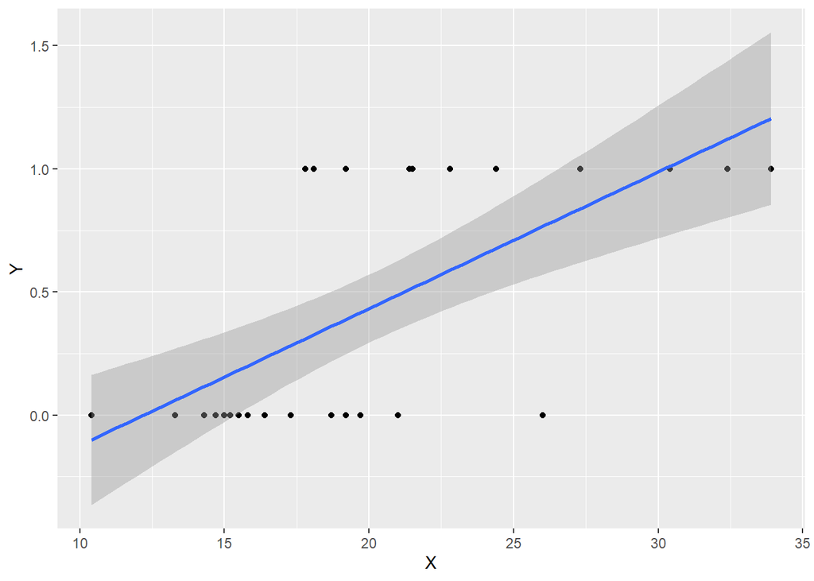

```
- to avoid this, we can use the logistic function to model
```

$p(X)$

```
  as follows:
```

$$\frac{p(X)}{1-p(X)}=e^{\beta_0+\beta_1X}$$

```
- where
```

$$\frac{p(X)}{1-p(X)}$$
are the odds ratio

[output not shown]

And we have our probability between 0 and 1.

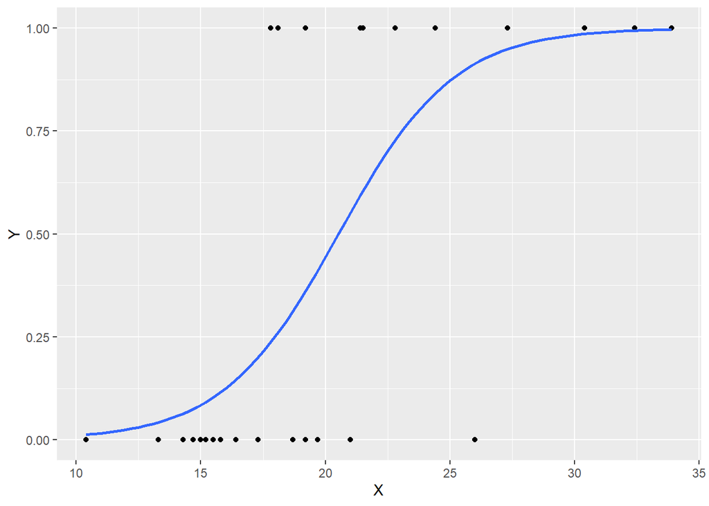

```
- a logistic regression models the probability that its outcome belongs to a certain category
```

- Model building strategy:

  ```
    a) univariate analysis


    b) multivariate analysis


    c) refitting the model


    d) goodness of fit
  ```

### The need for logistic regression